# fin

Bay Area Bike Sharing Trips

*Anonymized bike trip data from Jan 2019 to March 2019*

*Exploratory Data Analysis (EDA) by Kevin Francisco Chacón Vargas, September 2020*

[figure not shown]

## Context

The individualized mobility projects, in this case bycicles, have been growing in the last 10 years, as an alternative and solution to traffic congestion and environmental pollution. As DeMaio (2020) points in his blog, the growth of this type of projects has gone from one every couple of weeks to one each day. Fact that denotes that bike-sharing is a low-cost alternative (compared to other models of transportation) and both the public and private sectors can have great benefits from its implementation.  
For these reasons, the following notebook presents an Exploratory Data Analysis of the Bay Area from January 2019 to March 2019 as an introduction to the matter of bike-sharing and some interesting facts that the data analyzed denotes.

## Objectives

General objective:

Elaborate an Exploratory Data Analysis of the Bay Area dataset from January 2019 to March 2019 to find *insights* that suggest the distribution and behaviour of the use of bike-sharing.

Specific objetives:

Perform a cleansing and transformation of the data prior to its analysis.

Use the Pandas, Numpy, Matplotlib and Seaborn packages to normalize, map and visualize the information.

Compute mathematical operations to understand the behaviour of data.

Generate conclusions and suggestions about the data.

## Section #1: About the dataset

The files are available at: https://www.kaggle.com/jolasa/bay-area-bike-sharing-trips

Semantic analysis

As it is shown in the following table, the dataset is quite clear. It does not use coding or abbreviations that make it difficult to understand the significant of its attributes.

Structural analysis

To understand the structure of the dataset, the files correponding to January-March (2019) are going to be ingested as well as the libraries.

```python
%matplotlib inline
import pandas as pd
import numpy as np
import seaborn as sns
import matplotlib.pyplot as plt
from matplotlib import cm
import warnings
warnings.filterwarnings('ignore')
```

```python
jan= pd.read_csv("jan_2019.csv")
feb = pd.read_csv("feb_2019.csv")
mar = pd.read_csv("mar_2019.csv")

list([jan.columns," ", feb.columns," ",mar.columns])
```

```
[Index(['month', 'trip_duration_sec', 'start_station_id', 'start_station_name',
        'end_station_id', 'end_station_name', 'bike_id', 'user_type',
        'member_birth_year', 'member_gender'],
       dtype='object'),
 ' ',
 Index(['month', 'trip_duration_sec', 'start_station_id', 'start_station_name',
        'end_station_id', 'end_station_name', 'bike_id', 'user_type',
        'member_birth_year', 'member_gender'],
       dtype='object'),
 ' ',
 Index(['month', 'trip_duration_sec', 'start_station_id', 'start_station_name',
        'end_station_id', 'end_station_name', 'bike_id', 'user_type',
        'member_birth_year', 'member_gender'],
       dtype='object')]
```

Knowing that the three datasets have the same structure, they can be merged into a single dataframe.

```python
df = jan.append(feb, ignore_index=True)
df = df.append(mar, ignore_index=True)
df.info()
```

```
<class 'pandas.core.frame.DataFrame'>
RangeIndex: 631793 entries, 0 to 631792
Data columns (total 10 columns):
 #   Column              Non-Null Count   Dtype
---  ------              --------------   -----
 0   month               631793 non-null  object
 1   trip_duration_sec   631793 non-null  int64
 2   start_station_id    631127 non-null  float64
 3   start_station_name  631127 non-null  object
 4   end_station_id      631127 non-null  float64
 5   end_station_name    631127 non-null  object
 6   bike_id             631793 non-null  int64
 7   user_type           631793 non-null  object
 8   member_birth_year   602085 non-null  float64
 9   member_gender       602088 non-null  object
dtypes: float64(3), int64(2), object(5)
memory usage: 48.2+ MB
```

As it is seen, the dataset has three types of data: float64, int64 and objects. Likewise, there is a total of 10 columns being the maximum number of rows 631,793. According to this, the attributes "start_station_id", "start_station_name", "end_station_id", "end_station_name","member_birth_year" and "member_gender" have NaN values. This issue is going to be treated in the following section.

For now, lets have a better view of the dataframe.

```python
df.head(5)
```

|  | month | trip_duration_sec | start_station_id | start_station_name | end_station_id | end_station_name | bike_id | user_type | member_birth_year | member_gender |
| --- | --- | --- | --- | --- | --- | --- | --- | --- | --- | --- |
| 0 | January | 80825 | 229.0 | Foothill Blvd at 42nd Ave | 196.0 | Grand Ave at Perkins St | 4861 | Subscriber | 1989.0 | Male |
| 1 | January | 65900 | 4.0 | Cyril Magnin St at Ellis St | 134.0 | Valencia St at 24th St | 5506 | Subscriber | 1989.0 | Male |
| 2 | January | 62633 | 245.0 | Downtown Berkeley BART | 157.0 | 65th St at Hollis St | 2717 | Customer | 1965.0 | Female |
| 3 | January | 44680 | 85.0 | Church St at Duboce Ave | 53.0 | Grove St at Divisadero | 4557 | Customer | 1974.0 | Male |
| 4 | January | 60709 | 16.0 | Steuart St at Market St | 28.0 | The Embarcadero at Bryant St | 2100 | Customer | NaN | NaN |

```python
df.tail(5)
```

|  | month | trip_duration_sec | start_station_id | start_station_name | end_station_id | end_station_name | bike_id | user_type | member_birth_year | member_gender |
| --- | --- | --- | --- | --- | --- | --- | --- | --- | --- | --- |
| 631788 | March | 451 | 78.0 | Folsom St at 9th St | 136.0 | 23rd St at San Bruno Ave | 5410 | Subscriber | 1992.0 | Male |
| 631789 | March | 390 | 75.0 | Market St at Franklin St | 78.0 | Folsom St at 9th St | 6286 | Subscriber | 1974.0 | Male |
| 631790 | March | 231 | 317.0 | San Salvador St at 9th St | 310.0 | San Fernando St at 4th St | 6198 | Subscriber | 1994.0 | Male |
| 631791 | March | 257 | 235.0 | Union St at 10th St | 160.0 | West Oakland BART Station | 5096 | Subscriber | 1990.0 | Other |
| 631792 | March | 149 | 180.0 | Telegraph Ave at 23rd St | 220.0 | San Pablo Ave at MLK Jr Way | 4485 | Subscriber | 1983.0 | Male |

As the tables show, the information presented in the dataset tell us about the trips done from January 2019 to March 2019, the duration (in secs) of each trip, the start and end point and some information about the user. Specifically, if the user has a subscription, the birth year and its gender.

## Section #2: Data Cleansing Process

A very crucial step of the data preparation is the process of identifying and correcting messy and raw data. In the case of the dataset that is been analyzed all the attributes presented are useful for get insights and there are just two little issues with them: NaN values and (probably) values without any sense in the member_birth_year column.

To solve this, lets start seeing how many of NaN values exist in each attribute.

```python
df.isnull().sum()
```

```
month                     0
trip_duration_sec         0
start_station_id        666
start_station_name      666
end_station_id          666
end_station_name        666
bike_id                   0
user_type                 0
member_birth_year     29708
member_gender         29705
dtype: int64
```

As can be seen, the NaN values exist in two kind of categories of attributes. One that has information about the stations and another one that has data about the users. For an adequate treatment, lets divide its cleansing in two parts. In this sense, we can avoid any misunderstanding of the data and how it must be treated.

Lets start with the attributes that have information about the users.

member_birth_year

As there is no other attribute where we can infer the birth_year of the user, lets see what is the range of years that the dataset has. With this, we will know if there are years that does not make any sense (e.g. 1800, etc.) and also, lets establish a year for the NaN values that does not create any bias over the other data.

```python
by_min= df["member_birth_year"].min()
by_max= df["member_birth_year"].max()
list([by_min,by_max])
```

```
[1878.0, 2001.0]
```

As it was supposed, the attribute has a set of birth years that couldn't be possible. This issue is common due to the user can create an account in the app and as part of the registration form has to define a birth year. This value is selected with a dropdown list or calendar and most applications do not have any restrictions for the values that are presented to the user.

Now, the information that gives us this column help us to define a consumer profile (based on its age). For this reason, as a first step lets compute what is the percentage of values that are NaN and the ones that (probably) does not have any sense. This will alert us if the percentages are significant or not. Then, lets assign a value of 0 to the NaN cases.

```python
nan_cases_percentage = (df["member_birth_year"].isnull().sum() / df["member_birth_year"].count()) * 100

print("Percentage of NaN values in member_birth_year: ", round(nan_cases_percentage,2),"%")
```

```
Percentage of NaN values in member_birth_year:  4.93 %
```

```python
#Lets assume that 100 years old is the maximum age that is considered to ride a bike
outliers_cases = df[df.member_birth_year < 1919]

outliers_cases_percentage = (outliers_cases["member_birth_year"].count() / df["member_birth_year"].count()) * 100
print("Percentage of outlier values (+100 years old users) in member_birth_year: ",
      round(outliers_cases_percentage,2),"%")
```

```
Percentage of outlier values (+100 years old users) in member_birth_year:  0.05 %
```

```python
#Assing a zero-value to NaN cases
df["member_birth_year"].fillna(0, inplace=True)
```

member_gender

The member gender is a very important value to create a profile of our target. However, it is known that some people prefer to not specify its gender as "male" or "female". The analysis of its reason is not the focus of this EDA, therefore, for the moment lets change the NaN value for a "Not defined".

```python
df["member_gender"] = df["member_gender"].replace(np.nan, "Not defined", regex=True)
```

```python
df.isnull().sum()
```

```
month                   0
trip_duration_sec       0
start_station_id      666
start_station_name    666
end_station_id        666
end_station_name      666
bike_id                 0
user_type               0
member_birth_year       0
member_gender           0
dtype: int64
```

Having done the attributes that refer to information about the users, lets focus on the columns that have data about the stations.

start_station_id || start_station_name || end_station_id || end_station_name

Giving an hypothesis about the missed data here and since the bikes are the ones that should receive/communicate the place where they are each time they arrive to a station, it seems that the problem comes from the sensors of the bikes. Trying to map the problem in an ease way, lets imgine that when the bike arrives to the station "A" there is a communication between the station and the bike that registers the id_station to the bike. In this sense, the bike can create a record of its trips everytime it leaves and arrives to a station.

Taking the previous explanation as a possible one, lets create a filtered dataset to validate if the problem is focused in some bikes.

```python
nan_filtered_df = df[df["start_station_id"].isnull()]
nan_filtered_df
```

|  | month | trip_duration_sec | start_station_id | start_station_name | end_station_id | end_station_name | bike_id | user_type | member_birth_year | member_gender |
| --- | --- | --- | --- | --- | --- | --- | --- | --- | --- | --- |
| 2023 | January | 746 | NaN | NaN | NaN | NaN | 4244 | Subscriber | 1976.0 | Male |
| 2533 | January | 278 | NaN | NaN | NaN | NaN | 4249 | Subscriber | 1992.0 | Female |
| 3089 | January | 830 | NaN | NaN | NaN | NaN | 4208 | Subscriber | 1986.0 | Male |
| 5264 | January | 562 | NaN | NaN | NaN | NaN | 4208 | Subscriber | 1986.0 | Male |
| 5833 | January | 1676 | NaN | NaN | NaN | NaN | 4251 | Customer | 1990.0 | Female |
| ... | ... | ... | ... | ... | ... | ... | ... | ... | ... | ... |
| 624677 | March | 899 | NaN | NaN | NaN | NaN | 4174 | Subscriber | 1980.0 | Male |
| 625046 | March | 155 | NaN | NaN | NaN | NaN | 4283 | Subscriber | 1988.0 | Male |
| 627556 | March | 228 | NaN | NaN | NaN | NaN | 3975 | Subscriber | 1994.0 | Male |
| 629400 | March | 138 | NaN | NaN | NaN | NaN | 4283 | Subscriber | 1988.0 | Male |
| 630842 | March | 832 | NaN | NaN | NaN | NaN | 4174 | Subscriber | 1980.0 | Male |

666 rows × 10 columns

```python
bikes_id= nan_filtered_df["bike_id"].unique()
bikes_id
```

```
array([4244, 4249, 4208, 4251, 4092, 4157, 4098, 4105, 4113, 4261, 4232,
       4241, 4174, 3975, 4107, 4093, 4199, 4246, 4126, 4148, 4095, 4189,
       4121, 4120, 4123, 4162, 4211, 4283, 4089, 4150, 4091, 4168, 4239,
       4250, 4124, 4141, 4197, 4207, 4245, 4165, 4130, 4125, 4275, 4085,
       4270, 4081, 4146, 4137, 4172, 4194], dtype=int64)
```

```python
print("Number of bikes that do not register the station's id:", bikes_id.size)
```

```
Number of bikes that do not register the station's id: 50
```

```python
# this is a statement to proof that those bikes have never registered any station's id
# It is intended for the reader that wants to validate the previous affirmation
df[df.bike_id == 4244]
```

|  | month | trip_duration_sec | start_station_id | start_station_name | end_station_id | end_station_name | bike_id | user_type | member_birth_year | member_gender |
| --- | --- | --- | --- | --- | --- | --- | --- | --- | --- | --- |
| 2023 | January | 746 | NaN | NaN | NaN | NaN | 4244 | Subscriber | 1976.0 | Male |
| 8491 | January | 732 | NaN | NaN | NaN | NaN | 4244 | Subscriber | 1976.0 | Male |
| 10453 | January | 757 | NaN | NaN | NaN | NaN | 4244 | Subscriber | 1976.0 | Male |
| 33624 | January | 15849 | NaN | NaN | NaN | NaN | 4244 | Customer | 1965.0 | Male |
| 37608 | January | 4215 | NaN | NaN | NaN | NaN | 4244 | Customer | 1980.0 | Male |

As it is shown in the previos sections, it seems that 50 bikes do not register the station's id. Here is necessary an effort of the company to find those bicycles and repare them. However, for now lets focus in understand that those bikes are the only ones that are generating incomplete data and lets change the NaN values to "Unknown".

```python
df[("start_station_id")] = df[("start_station_id")].replace(np.nan, "Unknown", regex=True)
df[("start_station_name")] = df[("start_station_name")].replace(np.nan, "Unknown", regex=True)
df[("end_station_id")] = df[("end_station_id")].replace(np.nan, "Unknown", regex=True)
df[("end_station_name")] = df[("end_station_name")].replace(np.nan, "Unknown", regex=True)
```

Just as a remainder, it is important to understand how many values are being changed in terms of percentage. In the case of the bikes lets see how many of them are the ones that are having the problem of no-recording.

```python
bike_problem_perc = (nan_filtered_df["bike_id"].unique().size / df["bike_id"].unique().size) * 100
print("Percentage of bikes that do not register the station's id: ",
      round(bike_problem_perc,2),"%")
```

```
Percentage of bikes that do not register the station's id:  0.94 %
```

Now the company knows that near to 1% of it bicycles are presenting problems with the recording of the data.

Having done the changes, now lets validate that our dataset is free of NaN values.

```python
df.isnull().sum()
```

```
month                 0
trip_duration_sec     0
start_station_id      0
start_station_name    0
end_station_id        0
end_station_name      0
bike_id               0
user_type             0
member_birth_year     0
member_gender         0
dtype: int64
```

As a last point, lets validate if there is any misspelling in one of the values of "month", "user_type", or "member_gender"

```python
df["month"].unique()
```

```
array(['January', 'Februrary', 'March'], dtype=object)
```

As it is seen, there is a misspelling in February, lets change it.

```python
df[("month")] = df[("month")].replace("Februrary", "February", regex=True)
df["month"].unique()
```

```
array(['January', 'February', 'March'], dtype=object)
```

```python
df["user_type"].unique()
```

```
array(['Subscriber', 'Customer'], dtype=object)
```

```python
df["member_gender"].unique()
```

```
array(['Male', 'Female', 'Not defined', 'Other'], dtype=object)
```

## Section #3: Data Exploration and Visualization

According to the information that we have in our dataset, lets navigate our analysis in two parts:

1) Understanding the use of the bikes and the environment: This part is focused in the understanding of some general distributions of the data, the average trip duration and what are the most important factor to consider in order to gain clarity about the behaviour of the users.

2) Consumer profile, trends and strategies: Here, the analysis is focused in the creation of a consumer profile based on its demographic information and also, what seems to be the trends that can be deduce along the three months in study.

Specifically, lets answer the following questions:

- What's the average trip duration, in minutes?
- What's the service member age distribution? Are there significant behavioral differences between age groups?
- Are there any significant differences between subscribed and non-suscribed service members?
- Are there any significant differences in service use throughout time?
- What are the most used (top 10) stations for trip beginning and/or endings? Highlight behavior associated with these stations.

```python
df.head(5)
```

|  | month | trip_duration_sec | start_station_id | start_station_name | end_station_id | end_station_name | bike_id | user_type | member_birth_year | member_gender |
| --- | --- | --- | --- | --- | --- | --- | --- | --- | --- | --- |
| 0 | January | 80825 | 229 | Foothill Blvd at 42nd Ave | 196 | Grand Ave at Perkins St | 4861 | Subscriber | 1989.0 | Male |
| 1 | January | 65900 | 4 | Cyril Magnin St at Ellis St | 134 | Valencia St at 24th St | 5506 | Subscriber | 1989.0 | Male |
| 2 | January | 62633 | 245 | Downtown Berkeley BART | 157 | 65th St at Hollis St | 2717 | Customer | 1965.0 | Female |
| 3 | January | 44680 | 85 | Church St at Duboce Ave | 53 | Grove St at Divisadero | 4557 | Customer | 1974.0 | Male |
| 4 | January | 60709 | 16 | Steuart St at Market St | 28 | The Embarcadero at Bryant St | 2100 | Customer | 0.0 | Not defined |

### Understanding the use of the bikes and the environment

To begin, lets normalize the attribute "trip_duration_sec" to show it in minutes.

```python
df["trip_duration_min"] = round(df["trip_duration_sec"] / 60,2)
df = df.drop("trip_duration_sec", axis=1)
```

Now, lets understand the distribution of the time that the users are in the bikes. As it is shown in the following series, the mean time of riding a bike is **12.78 min** and the 75% of all users spend as long as 13.78min riding.

```python
df["trip_duration_min"].describe()
```

```
count    631793.000000
mean         12.780378
std          31.187891
min           1.020000
25%           5.530000
50%           8.820000
75%          13.780000
max        1427.930000
Name: trip_duration_min, dtype: float64
```

```python
q995 = df["trip_duration_min"].quantile(0.995)
print("The 99.5% of the trips last a maximum of: ",round(q995,2),"min")
```

```
The 99.5% of the trips last a maximum of:  113.42 min
```

So, with the previous validation now it is possible to say that all the trips that last more than 113.42min can be taken as outliers. In this sense, lets divide our dataset in two (one that work with the 99.5th percentile and another one with the outliers) and plot the frequency of the duration of the trips.

```python
df_995 = df[df.trip_duration_min <= 113.42]
df_25 = df[df.trip_duration_min > 113.42]
```

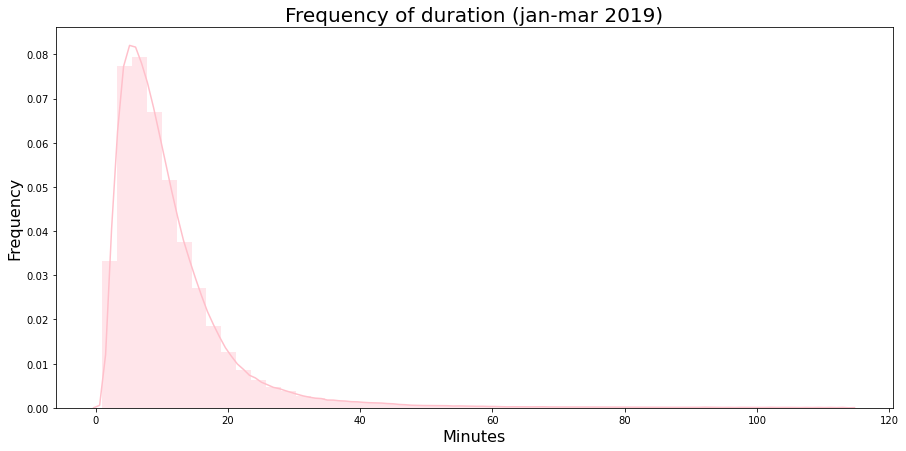

```python
#Configuring the canvas and points to be plotted
sns.set_color_codes()

fig, (ax1) = plt.subplots(1,1, figsize=(15,7))  # 1 row, 1columns

ax1 = sns.distplot(df_995["trip_duration_min"], color="pink")

ax1.set_title("Frequency of duration (jan-mar 2019)", fontsize=20)
ax1.set_xlabel("Minutes", fontsize=16)
ax1.set_ylabel("Frequency", fontsize=16)
```

As a referencia, lets plot the distribution of the dataset with the outliers. As it is usual, this dataset will be analyzed but the focus is going to be in the dataset with the 99.5% of the information.

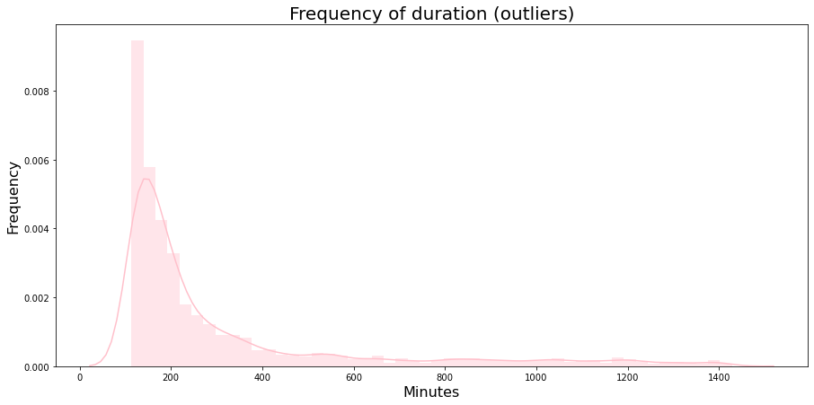

```python
sns.set_color_codes()

fig, (ax1) = plt.subplots(1,1, figsize=(15,7))  # 1 row, 1columns

ax1= sns.distplot(df_25["trip_duration_min"], color="pink", ax=ax1)

ax1.set_title("Frequency of duration (outliers)", fontsize=20)
ax1.set_xlabel("Minutes", fontsize=16)
ax1.set_ylabel("Frequency", fontsize=16)
```

Knowing what is the mean time of the trips, lets see what are the most used (top 10) stations and some of the main factors that influence to that.

To do this, lets create a dataframe with the names of the stations and the frequency that each of them appears in the dataset. In this manner, it will be really easy to know what are the most used stations.

```python
#Creating a dataframe with the frequencies of uses in each station.

#Start_stations
s_stations = pd.DataFrame(df["start_station_name"].value_counts())
s_stations = s_stations.reset_index()
s_stations =s_stations.rename(columns={"index":"start_station", "start_station_name":"frequency_start"})

#End_stations
e_stations = pd.DataFrame(df["end_station_name"].value_counts())
e_stations = e_stations.reset_index()

e_stations =e_stations.rename(columns={"index":"end_station", "end_station_name":"frequency_end"})
```

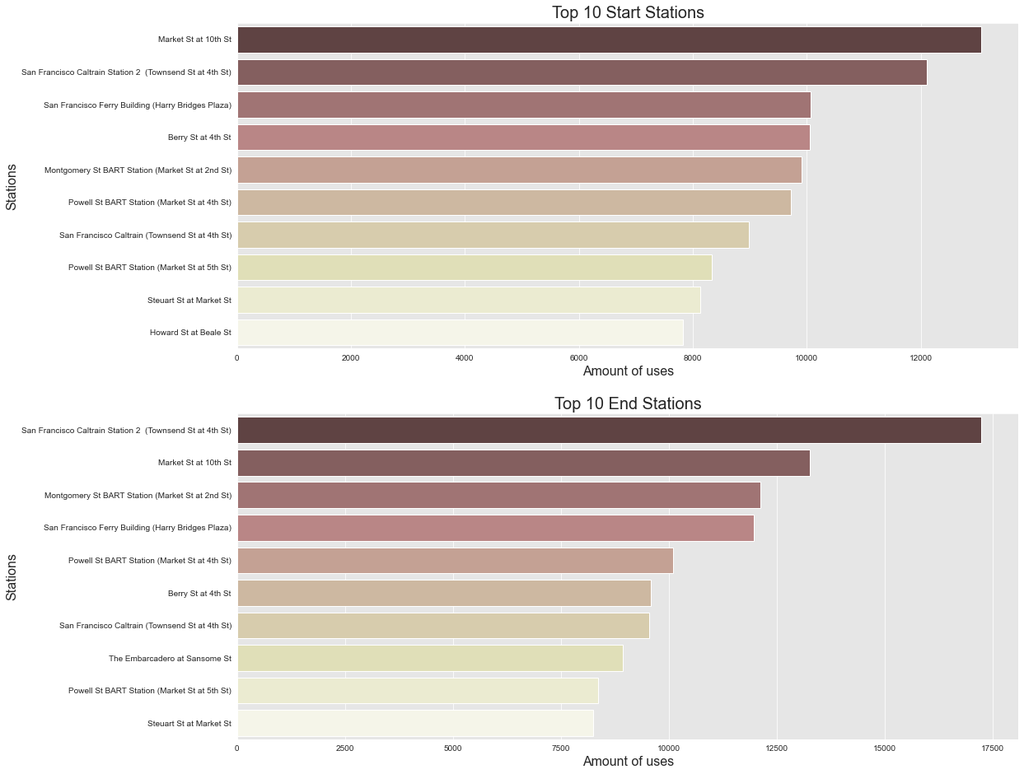

```python
#Plotting the top 10 stations
sns.set_style("darkgrid", {"axes.facecolor": ".9"})

fig, (ax1,ax2) = plt.subplots(2,1, figsize=(17,16))  # 1 row, 2 columns

#Plotting the top 10 start_stations
ax1= sns.barplot(x="frequency_start", y="start_station", data=s_stations[0:10], ax=ax1, palette=("pink"))
ax1.set_title("Top 10 Start Stations", fontsize=20)
ax1.set_xlabel("Amount of uses", fontsize=16)
ax1.set_ylabel("Stations", fontsize=16)


#Plotting the top 10 end_stations
ax2= sns.barplot(x="frequency_end", y="end_station", data=e_stations[0:10], ax=ax2, palette=("pink"))
ax2.set_title("Top 10 End Stations", fontsize=20)
ax2.set_xlabel("Amount of uses", fontsize=16)
ax2.set_ylabel("Stations", fontsize=16)
```

According to the previous references, we now know that the reason behind why these 10 stations are the most popular is because they are bus/train stations or hubs to other types of transportation.

Another important fact that must be taken into account is if there exist differences in the use of the bikes depending on the month. To analyze this, lets group the information month by month and also lets see the relation with each of the top stations.

To begin, lets see the trend of the use of bikes along the three months and validate if the climate could affect in the behaviour that is seen.

```python
#Since the result is based in the amount of minutes per month, lets avoid the outliers(df_25)
bikes_month = df_995[["month","trip_duration_min"]].groupby(by= "month").sum().sort_values(by="trip_duration_min",
                                                                                           ascending=False)
bikes_month = bikes_month.reset_index()

bikes_month =bikes_month.rename(columns={"index":"Month", "trip_duration_min":"total_min"})

#Lets create another column that help us normalize the scale of the values in the plot
bikes_month["total_min_plot"] = bikes_month["total_min"]/1000000

bikes_month
```

|  | month | total_min | total_min_plot |
| --- | --- | --- | --- |
| 0 | March | 2972725.61 | 2.972726 |
| 1 | January | 2145511.64 | 2.145512 |
| 2 | February | 1965820.44 | 1.965820 |

```python
#The following information was taken from www.usclimatedata.com and shows
#data collected from jan to mar 2019


climate_data = {"Month": ["January", "February", "March"],
               "Average_high_temp_(°F)": [59.9,55.1,61.3],
               "Average_low_temp_(°F)": [49.9,45.6,49.1],
               "Total_precipitation_(inch)": [5.13,7.94,4.31],
                "Total_snowfall": [0,0,0],
                "Highest_max_temp_(°F)": [66.0,62.1,73.0],
                "Lowest_max_temp_(°F)": [55.0,50.0,54.0],
                "Highest_min_temp_(°F)": [54.0,53.1,53.1],
                "Lowest_min_temp_(°F)": [42.1,39.9,45.0]
               }
climate_info = pd.DataFrame(climate_data,columns= ["Month",
                                                   "Average_high_temp_(°F)",
                                                  "Average_low_temp_(°F)",
                                                  "Total_precipitation_(inch)",
                                                  "Total_snowfall",
                                                  "Highest_max_temp_(°F)",
                                                  "Lowest_max_temp_(°F)",
                                                  "Highest_min_temp_(°F)",
                                                  "Lowest_min_temp_(°F)"])
climate_info
```

|  | Month | Average_high_temp_(°F) | Average_low_temp_(°F) | Total_precipitation_(inch) | Total_snowfall | Highest_max_temp_(°F) | Lowest_max_temp_(°F) | Highest_min_temp_(°F) | Lowest_min_temp_(°F) |
| --- | --- | --- | --- | --- | --- | --- | --- | --- | --- |
| 0 | January | 59.9 | 49.9 | 5.13 | 0 | 66.0 | 55.0 | 54.0 | 42.1 |
| 1 | February | 55.1 | 45.6 | 7.94 | 0 | 62.1 | 50.0 | 53.1 | 39.9 |
| 2 | March | 61.3 | 49.1 | 4.31 | 0 | 73.0 | 54.0 | 53.1 | 45.0 |

Lets see if this fact influenced over the use of bikes:

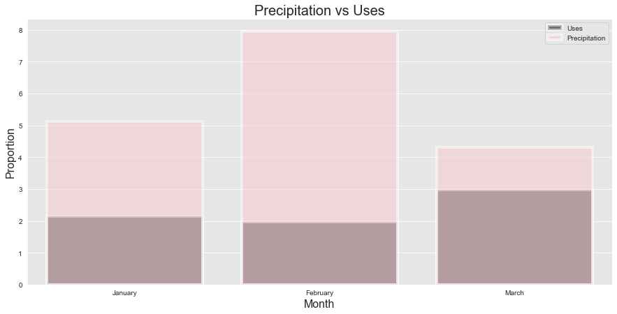

```python
sns.set_color_codes()

fig, (ax1) = plt.subplots(1,1, figsize=(15,7))  # 1 row, 1columns

sns.barplot(x="month", y="total_min_plot", data=bikes_month, order= ["January",
                                                                     "February","March"],
            color="black", alpha=0.5, label = "Uses", ax=ax1, linewidth=4)

sns.barplot(x="Month", y="Total_precipitation_(inch)", data=climate_info,
            color="pink",
            alpha=0.5,
            linewidth=4,
            label = "Precipitation",
            ax=ax1)

ax1.set_title("Precipitation vs Uses", fontsize=20)
ax1.set_xlabel("Month", fontsize=16)
ax1.set_ylabel("Proportion", fontsize=16)
ax1.legend()
```

As it was thought, it seems that due to precipitation there was a decrease over the use of bikes during February. This behaviour is also supported for the dynamic that is presented in the other months. As can be seen, March (the month where the precipation was the lowest) had the biggest use of bycicle and January also has a similar proportion between its precipitation and the use of bikes.

To understand the use of bicycles by station in each month, lets create a 2D table that provides us a summarization of this data.

```python
#As the analysis takes into account the amount of times that each station appear, there is no need to used a
#pre-filtered dataset

temp_list = df["start_station_name"].isin(s_stations.start_station[0:10])

top_start_stations = df[temp_list]

top_start_stations
```

|  | month | start_station_id | start_station_name | end_station_id | end_station_name | bike_id | user_type | member_birth_year | member_gender | trip_duration_min |
| --- | --- | --- | --- | --- | --- | --- | --- | --- | --- | --- |
| 4 | January | 16 | Steuart St at Market St | 28 | The Embarcadero at Bryant St | 2100 | Customer | 0.0 | Not defined | 1011.82 |
| 17 | January | 81 | Berry St at 4th St | 323 | Broadway at Kearny | 5480 | Subscriber | 1959.0 | Male | 12.18 |
| 22 | January | 3 | Powell St BART Station (Market St at 4th St) | 118 | Eureka Valley Recreation Center | 5193 | Subscriber | 1965.0 | Male | 24.75 |
| 54 | January | 67 | San Francisco Caltrain Station 2 (Townsend St... | 23 | The Embarcadero at Steuart St | 3652 | Subscriber | 1993.0 | Male | 8.98 |
| 59 | January | 16 | Steuart St at Market St | 28 | The Embarcadero at Bryant St | 1883 | Subscriber | 1979.0 | Male | 4.63 |
| ... | ... | ... | ... | ... | ... | ... | ... | ... | ... | ... |
| 631734 | March | 16 | Steuart St at Market St | 10 | Washington St at Kearny St | 5149 | Subscriber | 1982.0 | Female | 6.25 |
| 631744 | March | 58 | Market St at 10th St | 10 | Washington St at Kearny St | 4656 | Subscriber | 1982.0 | Male | 14.65 |
| 631746 | March | 81 | Berry St at 4th St | 93 | 4th St at Mission Bay Blvd S | 4619 | Customer | 1987.0 | Male | 4.33 |
| 631767 | March | 21 | Montgomery St BART Station (Market St at 2nd St) | 79 | 7th St at Brannan St | 6543 | Subscriber | 1989.0 | Male | 7.98 |
| 631783 | March | 5 | Powell St BART Station (Market St at 5th St) | 364 | China Basin St at 3rd St | 370 | Subscriber | 1986.0 | Male | 10.42 |

98202 rows × 10 columns

```python
#Grouping the data and creating the pivot table
start_stations_grouped =top_start_stations[["month","start_station_name"]].groupby(by="month")

start_stations_grouped = start_stations_grouped['start_station_name'].value_counts().to_frame(name = 'Uses').reset_index()
start_stations_pivoted = start_stations_grouped.pivot_table(start_stations_grouped, index="month", columns ="start_station_name")
start_stations_pivoted
```

| start_station_name month | Uses Berry St at 4th St | Uses Howard St at Beale St | Uses Market St at 10th St | Uses Montgomery St BART Station (Market St at 2nd St) | Uses Powell St BART Station (Market St at 4th St) | Uses Powell St BART Station (Market St at 5th St) | Uses San Francisco Caltrain (Townsend St at 4th St) | Uses San Francisco Caltrain Station 2 (Townsend St at 4th St) | Uses San Francisco Ferry Building (Harry Bridges Plaza) | Uses Steuart St at Market St |
| --- | --- | --- | --- | --- | --- | --- | --- | --- | --- | --- |
| February | 3052 | 2293 | 3904 | 2895 | 2760 | 2327 | 2703 | 3544 | 2710 | 2283 |
| January | 3133 | 2634 | 3853 | 3166 | 3113 | 2539 | 3055 | 3775 | 3115 | 2626 |
| March | 3871 | 2905 | 5307 | 3844 | 3854 | 3467 | 3219 | 4786 | 4248 | 3221 |

As the pivot_table orders the rows alphabetically, lets reindex them in the correct order.

```python
row_order = ["January", "February","March"]
start_stations_pivoted = start_stations_pivoted.reindex(row_order, axis=0)

start_stations_pivoted
```

| start_station_name month | Uses Berry St at 4th St | Uses Howard St at Beale St | Uses Market St at 10th St | Uses Montgomery St BART Station (Market St at 2nd St) | Uses Powell St BART Station (Market St at 4th St) | Uses Powell St BART Station (Market St at 5th St) | Uses San Francisco Caltrain (Townsend St at 4th St) | Uses San Francisco Caltrain Station 2 (Townsend St at 4th St) | Uses San Francisco Ferry Building (Harry Bridges Plaza) | Uses Steuart St at Market St |
| --- | --- | --- | --- | --- | --- | --- | --- | --- | --- | --- |
| January | 3133 | 2634 | 3853 | 3166 | 3113 | 2539 | 3055 | 3775 | 3115 | 2626 |
| February | 3052 | 2293 | 3904 | 2895 | 2760 | 2327 | 2703 | 3544 | 2710 | 2283 |
| March | 3871 | 2905 | 5307 | 3844 | 3854 | 3467 | 3219 | 4786 | 4248 | 3221 |

Having the uses of each station by month, lets plot the trend that exists in each of them.

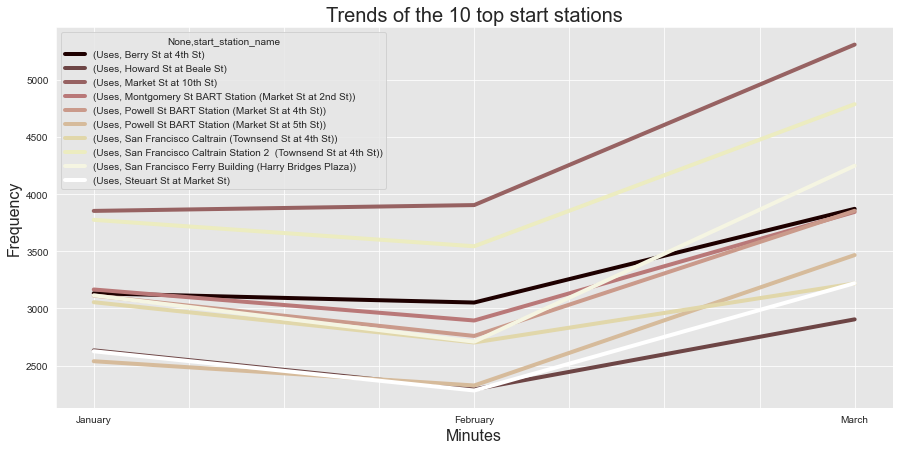

```python
fig, (ax1) = plt.subplots(1,1, figsize=(15,7))  # 1 row, 1columns

start_stations_pivoted.plot(ax=ax1, cmap=plt.get_cmap("pink"), linewidth=4)

ax1.set_title("Trends of the 10 top start stations", fontsize=20)
ax1.set_xlabel("Minutes", fontsize=16)
ax1.set_ylabel("Frequency", fontsize=16)
```

```python
#Lets do the same analysis with the "end_stations"

temp_list = df["end_station_name"].isin(e_stations.end_station[0:10])

top_end_stations = df[temp_list]


end_stations_grouped =top_end_stations[["month","end_station_name"]].groupby(by="month")

end_stations_grouped = end_stations_grouped['end_station_name'].value_counts().to_frame(name = 'Uses').reset_index()
end_stations_pivoted = end_stations_grouped.pivot_table(end_stations_grouped, index="month", columns ="end_station_name")

column_order = ["January", "February","March"]
end_stations_pivoted = end_stations_pivoted.reindex(column_order, axis=0)

end_stations_pivoted
```

| end_station_name month | Uses Berry St at 4th St | Uses Market St at 10th St | Uses Montgomery St BART Station (Market St at 2nd St) | Uses Powell St BART Station (Market St at 4th St) | Uses Powell St BART Station (Market St at 5th St) | Uses San Francisco Caltrain (Townsend St at 4th St) | Uses San Francisco Caltrain Station 2 (Townsend St at 4th St) | Uses San Francisco Ferry Building (Harry Bridges Plaza) | Uses Steuart St at Market St | Uses The Embarcadero at Sansome St |
| --- | --- | --- | --- | --- | --- | --- | --- | --- | --- | --- |
| January | 3038 | 3985 | 3733 | 3239 | 2493 | 3582 | 5244 | 3692 | 2663 | 2752 |
| February | 2872 | 3973 | 3647 | 2997 | 2353 | 2947 | 4857 | 3368 | 2338 | 2512 |
| March | 3669 | 5304 | 4746 | 3860 | 3516 | 3010 | 7139 | 4910 | 3237 | 3671 |

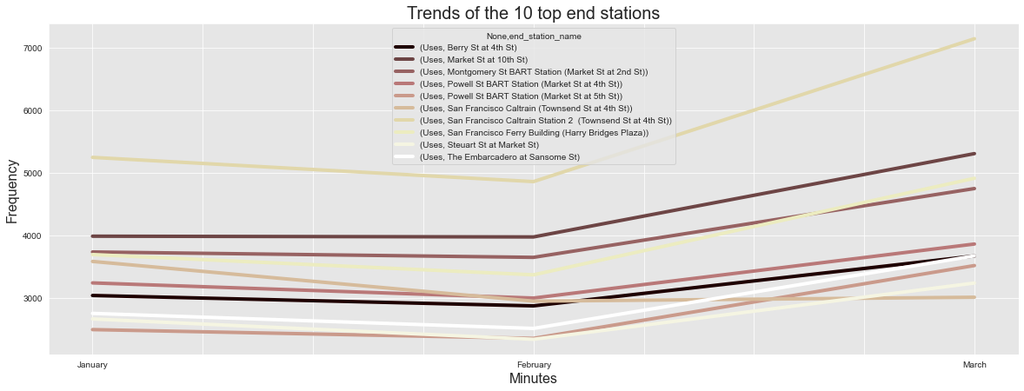

```python
fig, (ax1) = plt.subplots(1,1, figsize=(20,7))  # 1 row, 1columns

end_stations_pivoted.plot(ax=ax1, cmap=plt.get_cmap("pink"), linewidth=4)

ax1.set_title("Trends of the 10 top end stations", fontsize=20)
ax1.set_xlabel("Minutes", fontsize=16)
ax1.set_ylabel("Frequency", fontsize=16)
```

As can be seen, the only difference between the increase that is observed in the start_stations and end_stations is that it seems that San Francisco Caltrain (Townsend St at 4th St) has a decreasing trend. Doing some research in the Internet it was found that this station is under remodelation and it is next to soon-to-be-completed subway stations. However, this is just a clue about what could be the reason but, the sources of information was not official and they are just taken as superficial references.

### Consumer profile, trends and strategies

Continuing with the second part of the analysis and visualization of the information, lets start plotting the distribution of users by age. Since there is no affectation in using the complete dataset, lets add it a new column with the corresponding age of each user (in years).

```python
df
```

|  | month | start_station_id | start_station_name | end_station_id | end_station_name | bike_id | user_type | member_birth_year | member_gender | trip_duration_min |
| --- | --- | --- | --- | --- | --- | --- | --- | --- | --- | --- |
| 0 | January | 229 | Foothill Blvd at 42nd Ave | 196 | Grand Ave at Perkins St | 4861 | Subscriber | 1989.0 | Male | 1347.08 |
| 1 | January | 4 | Cyril Magnin St at Ellis St | 134 | Valencia St at 24th St | 5506 | Subscriber | 1989.0 | Male | 1098.33 |
| 2 | January | 245 | Downtown Berkeley BART | 157 | 65th St at Hollis St | 2717 | Customer | 1965.0 | Female | 1043.88 |
| 3 | January | 85 | Church St at Duboce Ave | 53 | Grove St at Divisadero | 4557 | Customer | 1974.0 | Male | 744.67 |
| 4 | January | 16 | Steuart St at Market St | 28 | The Embarcadero at Bryant St | 2100 | Customer | 0.0 | Not defined | 1011.82 |
| ... | ... | ... | ... | ... | ... | ... | ... | ... | ... | ... |
| 631788 | March | 78 | Folsom St at 9th St | 136 | 23rd St at San Bruno Ave | 5410 | Subscriber | 1992.0 | Male | 7.52 |
| 631789 | March | 75 | Market St at Franklin St | 78 | Folsom St at 9th St | 6286 | Subscriber | 1974.0 | Male | 6.50 |
| 631790 | March | 317 | San Salvador St at 9th St | 310 | San Fernando St at 4th St | 6198 | Subscriber | 1994.0 | Male | 3.85 |
| 631791 | March | 235 | Union St at 10th St | 160 | West Oakland BART Station | 5096 | Subscriber | 1990.0 | Other | 4.28 |
| 631792 | March | 180 | Telegraph Ave at 23rd St | 220 | San Pablo Ave at MLK Jr Way | 4485 | Subscriber | 1983.0 | Male | 2.48 |

631793 rows × 10 columns

```python
df["age"] = 2019 - df["member_birth_year"] #Note that the age is calculated taken 2019 as the current year.

df
```

|  | month | start_station_id | start_station_name | end_station_id | end_station_name | bike_id | user_type | member_birth_year | member_gender | trip_duration_min | age |
| --- | --- | --- | --- | --- | --- | --- | --- | --- | --- | --- | --- |
| 0 | January | 229 | Foothill Blvd at 42nd Ave | 196 | Grand Ave at Perkins St | 4861 | Subscriber | 1989.0 | Male | 1347.08 | 30.0 |
| 1 | January | 4 | Cyril Magnin St at Ellis St | 134 | Valencia St at 24th St | 5506 | Subscriber | 1989.0 | Male | 1098.33 | 30.0 |
| 2 | January | 245 | Downtown Berkeley BART | 157 | 65th St at Hollis St | 2717 | Customer | 1965.0 | Female | 1043.88 | 54.0 |
| 3 | January | 85 | Church St at Duboce Ave | 53 | Grove St at Divisadero | 4557 | Customer | 1974.0 | Male | 744.67 | 45.0 |
| 4 | January | 16 | Steuart St at Market St | 28 | The Embarcadero at Bryant St | 2100 | Customer | 0.0 | Not defined | 1011.82 | 2019.0 |
| ... | ... | ... | ... | ... | ... | ... | ... | ... | ... | ... | ... |
| 631788 | March | 78 | Folsom St at 9th St | 136 | 23rd St at San Bruno Ave | 5410 | Subscriber | 1992.0 | Male | 7.52 | 27.0 |
| 631789 | March | 75 | Market St at Franklin St | 78 | Folsom St at 9th St | 6286 | Subscriber | 1974.0 | Male | 6.50 | 45.0 |
| 631790 | March | 317 | San Salvador St at 9th St | 310 | San Fernando St at 4th St | 6198 | Subscriber | 1994.0 | Male | 3.85 | 25.0 |
| 631791 | March | 235 | Union St at 10th St | 160 | West Oakland BART Station | 5096 | Subscriber | 1990.0 | Other | 4.28 | 29.0 |
| 631792 | March | 180 | Telegraph Ave at 23rd St | 220 | San Pablo Ave at MLK Jr Way | 4485 | Subscriber | 1983.0 | Male | 2.48 | 36.0 |

631793 rows × 11 columns

```python
df["age"].describe()
```

```
count    631793.000000
mean        127.641674
std         420.244022
min          18.000000
25%          27.000000
50%          33.000000
75%          41.000000
max        2019.000000
Name: age, dtype: float64
```

As was commented during the cleasing of the data, there are some values in the birth_year column that do not make any sense (ages over 100 years old). However, they only represent a 0.05% of the information, justification of why they were not deleted. Likewise, the NaN values were updated to 0 and that provokes that the mean of the age described in the previous table does not represent an accurate value. In this sense, lets put our attention on the values described by the quantiles (25%, 50% and 75%) to get a real glance about the range of age that the users have.

As can be seen, the 75% of the users are 41 years old or younger, however, lets extend a little more the percentage of the information taken into account to discover a bigger range of age.

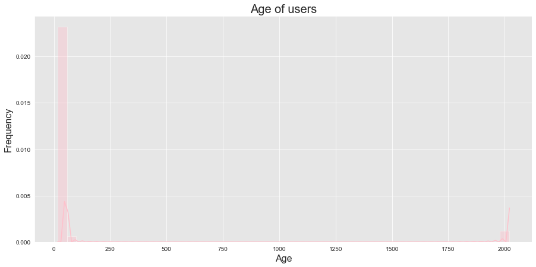

```python
fig, (ax1) = plt.subplots(1,1, figsize=(15,7))  # 1 row, 1columns

ax1= sns.distplot(df["age"], color="pink", ax=ax1)

ax1.set_title("Age of users", fontsize=20)
ax1.set_xlabel("Age", fontsize=16)
ax1.set_ylabel("Frequency", fontsize=16)
```

As it was done with the time of the trips, lets compute the percentile 99.5th and see what is the maximum value of the age in this range of data.

```python
q995 = df["age"].quantile(0.995)
print("The 99.5% of the users are: ",round(q995,2),"years old or younger")
```

```
The 99.5% of the users are:  2019.0 years old or younger
```

In this case, if we take the 99.5% of the data the outliers and zero-values are also taken into account. To solve it, lets try it with the 95th percentile.

```python
q95 = df["age"].quantile(0.95)
print("The 95% of the users are: ",round(q95,2),"years old or younger")
```

```
The 95% of the users are:  71.0 years old or younger
```

```python
#According to the 95th percentile, lets use the age of 71 to filtered our data

under_71 = df["age"] <= 71

df_95 = df[under_71]
```

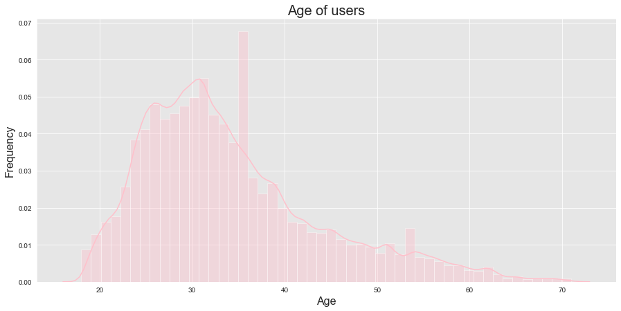

```python
fig, (ax1) = plt.subplots(1,1, figsize=(15,7))  # 1 row, 1columns

ax1= sns.distplot(df_95["age"], color="pink", ax=ax1)

ax1.set_title("Age of users", fontsize=20)
ax1.set_xlabel("Age", fontsize=16)
ax1.set_ylabel("Frequency", fontsize=16)
```

```python
df_95["age"].describe()
```

```
count    600345.000000
mean         34.173350
std           9.709322
min          18.000000
25%          27.000000
50%          32.000000
75%          39.000000
max          71.000000
Name: age, dtype: float64
```

```python
print("The minimum age registered is:", df["age"].min(), "years old")
```

```
The minimum age registered is: 18.0 years old
```

Something interesting to note is that the minimum age of the users is 18 years old. This fact is according to the norm in the use of this kind of applications, payments, and insurances. At the same time, the 95% of the users are between 18 and 71 years old, placing themselves as Generation Z, Millenials, Generation X (and some Baby Boomers). This fact, along with the data presented by Pew Research Center (2019) about the adoption of technology that each generation has, supports the incremental trend in the use of bikes showed in previous charts. According to Pew, 73% of online Millenials (the ones that use internet services, smarthphones and apps in a regular basis) evaluates the internet as a good thing. This, coupled with the fact that ride a bike protects the environment, it is low-cost and it is healthy, convert this alternative to one with the biggest increment in popularity in the last years.

[figure not shown]

The previous chart presents information about the adoption of technology of each generation. Likewise, tell us that Millenials are the ones born from 1981 to 1996. Acoording to this, lets compute what are the percentage of users in each generation.

```python
#Calculating the percentages
silent = round(((df_95["member_birth_year"] <= 1946).sum())/df_95["member_birth_year"].count()*100,2)

baby_boomers = round((((df_95["member_birth_year"] > 1946) &
                 (df_95["member_birth_year"] <= 1964)).sum())/df_95["member_birth_year"].count()*100,2)

gen_x = round((((df_95["member_birth_year"] > 1964) & (df_95["member_birth_year"] <= 1980)).sum())/df_95["member_birth_year"].count()*100,2)

millenials = round((((df_95["member_birth_year"] > 1980) & (df_95["member_birth_year"] <= 1996)).sum())/df_95["member_birth_year"].count()*100,2)

gen_z = round((((df_95["member_birth_year"] > 1996)).sum())/df_95["member_birth_year"].count()*100,2)

#Creating a dict with the results
gen_dic= {"silent":silent,"baby_boomers":baby_boomers,"gen_x":gen_x,"millenials":millenials,"gen_z":gen_z}

#Converting our dict to a dataframe
gens = pd.DataFrame(list(gen_dic.items()), columns=["Generation","Users (%)"])
gens
```

|  | Generation | Users (%) |
| --- | --- | --- |
| 0 | silent | 0.00 |
| 1 | baby_boomers | 4.91 |
| 2 | gen_x | 21.31 |
| 3 | millenials | 67.91 |
| 4 | gen_z | 5.88 |

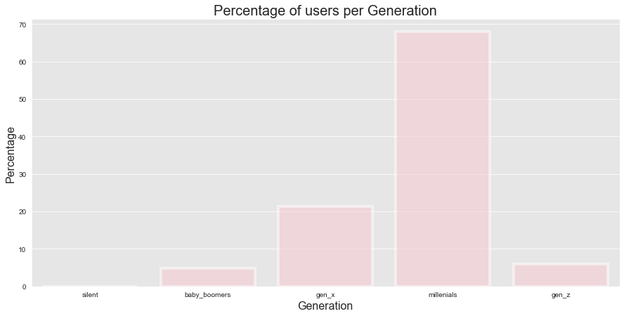

```python
fig, (ax1) = plt.subplots(1,1, figsize=(15,7))  # 1 row, 1columns

sns.barplot(x="Generation", y="Users (%)",data=gens,color="pink", alpha=0.5, label = "Uses", ax=ax1, linewidth=4)


ax1.set_title("Percentage of users per Generation", fontsize=20)
ax1.set_xlabel("Generation", fontsize=16)
ax1.set_ylabel("Percentage", fontsize=16)
```

Likewise, as Taine (2017) denotes it his blog, the Millenials are a generation of early-adopters and since the application was created in 2012, the adoption curve has been really fast.

To put it in detail, the vast majority of the users that are in the 95th percentile of the dataset belongs to the generation called "Millennials". Into this generation the behaviour of a significant portion of the people (referring to the adoption of technology) is described as "Early adopters". Having the following characteristics:

1) They are very active in social media and create reviews around new products.

2) They have a reasonable high social status and access to finances.

3) They have high levels of education and a reasonable approach to risk.

4) They have a degree of "thought leadearship" for other potential adopters.

All those facts combined help to a rapid adoption of alternatives as this one in which technology and a healthy alternative of transportation are involved. The next chart is a generalization of the adoption curve that exist with technology.

[figure not shown]

Now, lets analyze the proportion of users by gender and if they use a subscription in order to get the service.

```python
grouped_type_gender =df[["user_type","member_gender"]].groupby(by="user_type")

grouped_type_gender = grouped_type_gender['member_gender'].value_counts().to_frame(name = 'Amount').reset_index()
```

```python
grouped_type_gender_pivoted = grouped_type_gender.pivot_table(grouped_type_gender, index="member_gender",
                                                              columns ="user_type")
grouped_type_gender_pivoted
```

| user_type member_gender | Amount Customer | Amount Subscriber |
| --- | --- | --- |
| Female | 18751 | 124632 |
| Male | 45012 | 401573 |
| Not defined | 14736 | 14969 |
| Other | 1695 | 10425 |

The previous table summarizes the amount of customers and subscribers that exist per gender. As can be seen, in all cases there is more subscribers than customers. This is reasonable because the costs associated with the use of bikes are less if the person has a membership (subscription), having some other benefits too. At the same time, this shows that the efforts of the company to sell its memberships seems to generate value.

Now, lets see some behaviours in each on this dimensions. Lets star with the user_type:

```python
grouped_type =df[["month","user_type"]].groupby(by="month")

grouped_type = grouped_type['user_type'].value_counts().to_frame(name = 'Amount').reset_index()
grouped_type
```

|  | month | user_type | Amount |
| --- | --- | --- | --- |
| 0 | February | Subscriber | 163544 |
| 1 | February | Customer | 19868 |
| 2 | January | Subscriber | 168732 |
| 3 | January | Customer | 23350 |
| 4 | March | Subscriber | 219323 |
| 5 | March | Customer | 36976 |

In order to understand the proportion between subscribers and customers, lets compute the following:

```python
subscribers = grouped_type[grouped_type.user_type == "Subscriber"]
customers = grouped_type[grouped_type.user_type == "Customer"]
```

```python
print("The customers (people without a subscription) represent: ",
      round((customers["Amount"].sum()/subscribers["Amount"].sum())*100,2)
           ,"% of the total of users. Meaning that ",
      round(100-((customers["Amount"].sum()/subscribers["Amount"].sum())*100),2)
     ,"% of the users have a subscription.")
```

[output not shown]

Detailing a little more, lets see if there is a trend in the use of bikes by the subscribers and customers along the three months.

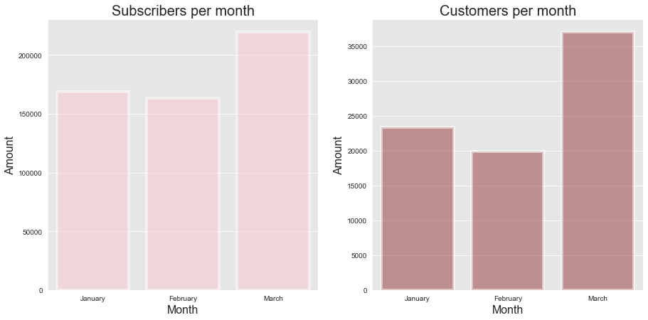

```python
fig, (ax1,ax2) = plt.subplots(1,2, figsize=(15,7))  # 1 row, 2 columns

sns.barplot(x="month", y="Amount", data=subscribers, order= ["January","February","March"],
            color="pink", alpha=0.5, ax=ax1, linewidth=4)

sns.barplot(x="month", y="Amount", data=customers,order= ["January","February","March"],
            color="brown", alpha=0.5,
            linewidth=4,
            ax=ax2)


ax1.set_title("Subscribers per month", fontsize=20)
ax1.set_xlabel("Month", fontsize=16)
ax1.set_ylabel("Amount", fontsize=16)

ax2.set_title("Customers per month", fontsize=20)
ax2.set_xlabel("Month", fontsize=16)
ax2.set_ylabel("Amount", fontsize=16)
```

As the charts show, there is a significant increase in the use of bikes (for subscribers as well as customers) in March. Also, it is shown that there was a bigger decreasing during Februray in the customers (the ones that do not have a membership) due to the high precipitation, as it was covered in the previous sections. This behaviour is reasonable since is expected that most of the subscribers keep their memberships during a month, even when its use could not be as frequent.

In order to have a quick view about the increasing and decreasing of the use of bikes between each month, lets write the following statements:

```python
#Subscribers variations

subs_jan = subscribers[subscribers.month == "January"]
subs_feb = subscribers[subscribers.month == "February"]
subs_mar = subscribers[subscribers.month == "March"]

total_subs_feb_jan = (subs_feb["Amount"].iloc[0] + subs_jan["Amount"].iloc[0])
total_subs_mar_feb = (subs_mar["Amount"].iloc[0] + subs_feb["Amount"].iloc[0])


subs_var_feb_jan = round(((subs_feb["Amount"].iloc[0] - subs_jan["Amount"].iloc[0])/total_subs_feb_jan)*100,2)

subs_var_mar_feb = round(((subs_mar["Amount"].iloc[0] - subs_feb["Amount"].iloc[0])/total_subs_mar_feb)*100,2)

#Customers variations

cust_jan = customers[customers.month == "January"]
cust_feb = customers[customers.month == "February"]
cust_mar = customers[customers.month == "March"]

total_cust_feb_jan = (cust_feb["Amount"].iloc[0] + cust_jan["Amount"].iloc[0])
total_cust_mar_feb = (cust_mar["Amount"].iloc[0] + cust_feb["Amount"].iloc[0])

cust_var_feb_jan = round(((cust_feb["Amount"].iloc[0] - cust_jan["Amount"].iloc[0])/total_cust_feb_jan)*100,2)

cust_var_mar_feb = round(((cust_mar["Amount"].iloc[0] - cust_feb["Amount"].iloc[0])/total_cust_mar_feb)*100,2)
```

```python
print("SUBSCRIBERS\n")
print("The variation in the use of bikes by subscribers between January and February is:",subs_var_feb_jan,"%")

print("The variation in the use of bikes by subscribers between February and March is:",subs_var_mar_feb,"%\n")

print("CUSTOMERS\n")
print("The variation in the use of bikes by customers between January and February is:",cust_var_feb_jan,"%")

print("The variation in the use of bikes by customers between February and March is:",cust_var_mar_feb,"%")
```

```
SUBSCRIBERS

The variation in the use of bikes by subscribers between January and February is: -1.56 %
The variation in the use of bikes by subscribers between February and March is: 14.57 %

CUSTOMERS

The variation in the use of bikes by customers between January and February is: -8.06 %
The variation in the use of bikes by customers between February and March is: 30.1 %
```

As it was mentioned before, there was a bigger decrease in the use of bikes by the customers during February. However, it is also valuable to denote that during March the biggest increase came from the customers; reaching as much as 30.1% of increment.

Another important fact is to know the generations in which the majority of the subscribers and customers are. In this manner, the company could understand what is its most valuable generations and how should apply its marketing strategies. This analysis is covered taken into account the 80th quantile, following the 80/20 Pareto methodology.

```python
range_subscribers = df_95[df_95.user_type == "Subscriber"]
q80 = range_subscribers["age"].quantile(0.80)
print("The 80% of the subscribers are:", q80,"years old or younger")
```

```
The 80% of the subscribers are: 42.0 years old or younger
```

According to this data and the segmentation per generation that the Pew Research Center gives, the majority of the subscribers belong to **Generation Z**, **Millenials** and **Generation X**.

```python
range_customers = df_95[df_95.user_type == "Customer"]
range_customers["age"].describe()


range_customers = df_95[df_95.user_type == "Customer"]
q80 = range_customers["age"].quantile(0.80)
print("The 80% of the customers are:", q80,"years old or younger")
```

```
The 80% of the customers are: 39.0 years old or younger
```

In the same way, the majority of the customers belong to those same generations.

Having this information the company has some insights for its marketing team and how they could design its strategies aligned with the characteristics of each generation. It is possible to go deeper and do some segmentation of the representation of each generation on each category (subscribers or customers).

The last data to be analyze is the distribution of the genres. Lets start viewing its proportion.

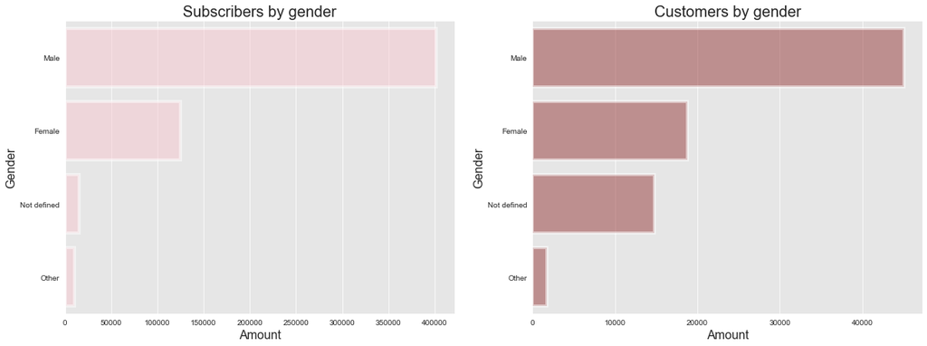

```python
#Creating two subs-dataset
cust_genders = grouped_type_gender[grouped_type_gender.user_type == "Customer"]
subs_genders = grouped_type_gender[grouped_type_gender.user_type == "Subscriber"]


#Ploting the number of users by gender

fig, (ax1,ax2) = plt.subplots(1,2, figsize=(20,7))  # 1 row, 2 columns

sns.barplot(x="Amount", y="member_gender", data=subs_genders, color="pink", alpha=0.5, ax=ax1, linewidth=4)

sns.barplot(x="Amount", y="member_gender", data=cust_genders, color="brown", alpha=0.5,
            linewidth=4,
            ax=ax2)


ax1.set_title("Subscribers by gender", fontsize=20)
ax1.set_xlabel("Amount", fontsize=16)
ax1.set_ylabel("Gender", fontsize=16)

ax2.set_title("Customers by gender", fontsize=20)
ax2.set_xlabel("Amount", fontsize=16)
ax2.set_ylabel("Gender", fontsize=16)
```

Another point is that in the case of customers is more common to not proportionate the information about its gender. This fact can be analyzed for the UX designers and validate if there exist an alternative to improve the process and capture this information. Likewise, the category "Not defined" was introduced as the treatment for the NaN values. This is important to denote because could help to identify if those cases were produce for an error of the system or a period of time where the app does not require to define a gender in order to use its services.

## Section #4: Conclusions and Suggestion

As it was denoted along this notebook, the dataset analyzed did not present any issue regarding to abbreviations or attributes that were difficult to understand. However, it had some issues regarding to NaN values that must be treated carefully to avoid any missunderstanding or bias of the information.

Likewise, the data gathered has two main focuses that are: 1) Information about stations and trips. 2) Information about the users.

Combining them it was possible to identify some trends about the uses of the bikes and also, an external factor (precipitation) that was related with the behaviour in February. Referring to the outliers, they were treated appropiately taking into account if the amount of values presented was representative and also, what was its influence over the other data.

In this manner, it was also possible to study the proportion of the data with respect to gender, age, time of the trip and the top 10 used stations. As well as, give some insights and suggestions that the company could use to communicate important behaviours and trends to its UX and Marketing department.

Related to suggestions, the primary will be to take action in finding the reasons why some data is being gathered as NaN and also, do some brainstorming to detect what other attributes could contribute to the objectives of the company and a more profound analysis of the information.

Finally, the EDA was created in a way that demonstrate the ability to manipulate the data and also, give a several ways to solve specific items, doing use of the structure of the elements that exist in the different libraries that were inmported.

## Section #5: References

Caltrain. (2020). Bikes and Caltrain. Taken from https://www.caltrain.com/riderinfo/Bicycles.html

DeMaio, P. (2020). The Bike-sharing Blog. Taken from http://bike-sharing.blogspot.com/

Lee, Casey & Wigginton, C. (2019). Cycling’s technological transformation: Making bicycling faster, easier, and safer. Taken from https://www2.deloitte.com/us/en/insights/industry/technology/technology-media-and-telecom-predictions/2020/bike-technology-transformation.html

SFMTA. (2020). Townsend Corridor Improvement Project. Taken from https://www.sfmta.com/projects/townsend-corridor-improvement-project

Taine, C. (2017). Are Millennials’ Shopping Behaviors Today, Everyone’s Shopping Behaviors Tomorrow? Taken from https://www.aciworldwide.com/insights/expert-view/2017/march/are-millennial-shopping-behaviors-today-everyones-shopping-behaviors-tomorrow

US Census Bureau. (2019). QuickFacts: Philadelphia County, Pennsylvania. Taken from https://www.census.gov/quickfacts/philadelphiacountypennsylvania

US Climate Data. (2019). Climate San Francisco - California. Taken from https://www.usclimatedata.com/climate/san-francisco/california/united-states/

Vogels, E. (2019). Millennials stand out for their technology use, but older generations also embrace digital life. Taken from https://www.pewresearch.org/fact-tank/2019/09/09/us-generations-technology-use/